# Part I - FORD GO BIKE

## by Matthew

## Investigation Overview

> In this investigation, I would look at the relationship between the age of the members, the duration of the bike trips, and the categorical variables.

## Dataset Overview

> The data consisted of over 100,000 records of bike trips. The attributes included the five categorical varables, as well as additional information such as the names of the stations, the latitudes and longitudes, and few others.

## UNIVARATE EXPLORATION

### DISTRIBUTION OF THE TRIPS BY THE AGE OF THE MEMBERS

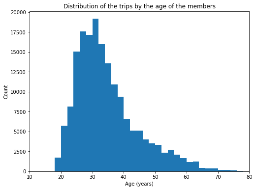

### DISTRIBUTION OF THE TRIPS BY THE DURATION OF THE TRIPS

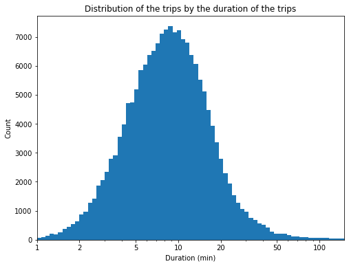

## BIVARIATE EXPLORATION

### RELATIONSHIP BETWEEN THE AGE OF THE MEMBERS AND THE DAYS OF THE WEEKS

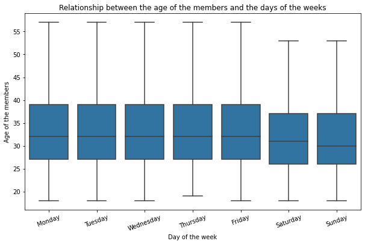

### RELATIONSHIP BETWEEN THE DURATION OF THE TRIPS AND THE DAYS OF THE WEEKS

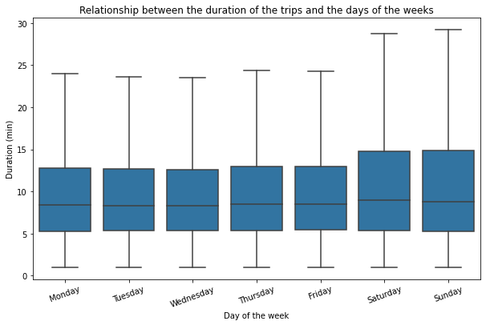

### RELATIONSHIP BETWEEN THE DURATION OF THE TRIPS AND THE OTHER CATEGORICAL VARIABLES

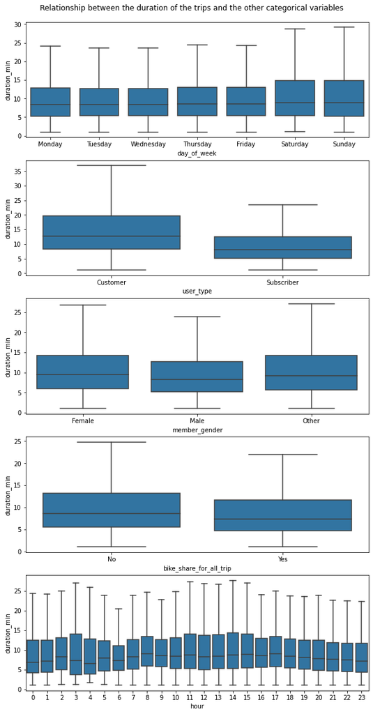

### RELATIONSHIP BETWEEN THE AGE OF THE MEMBERS AND THE OTHER CATEGORICAL VARIABLES

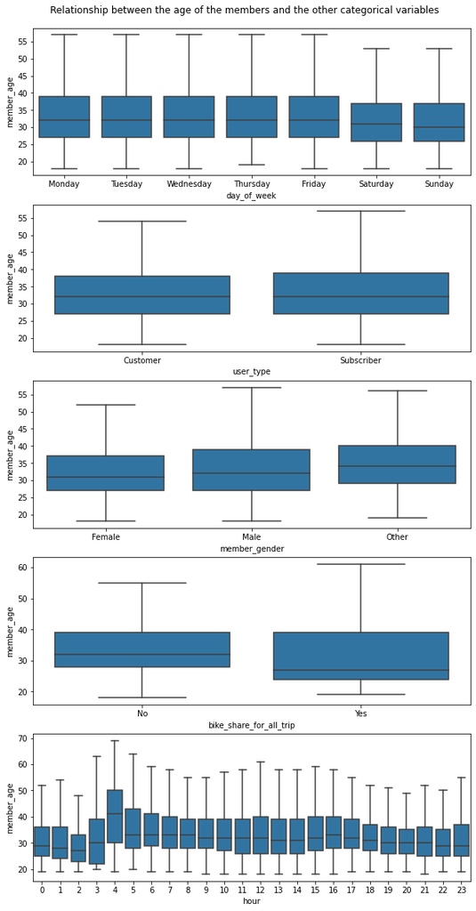

### RELATIONSHIP BETWEEN THE DURATION OF THE TRIPS AND THE AGE OF THE MEMBERS

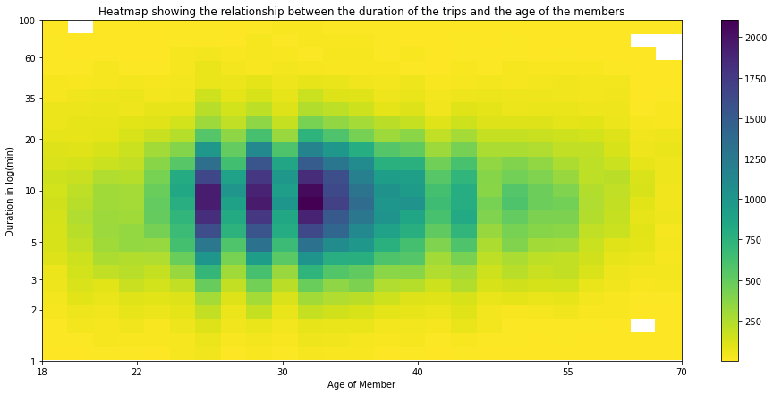

## MULTIVARIATE EXPLORATION

### RELATIONSHIP BETWEEN THE DURATION OF THE TRIPS, DAYS OF THE WEEK AND THE OTHER CATEGORICAL VARIABLES

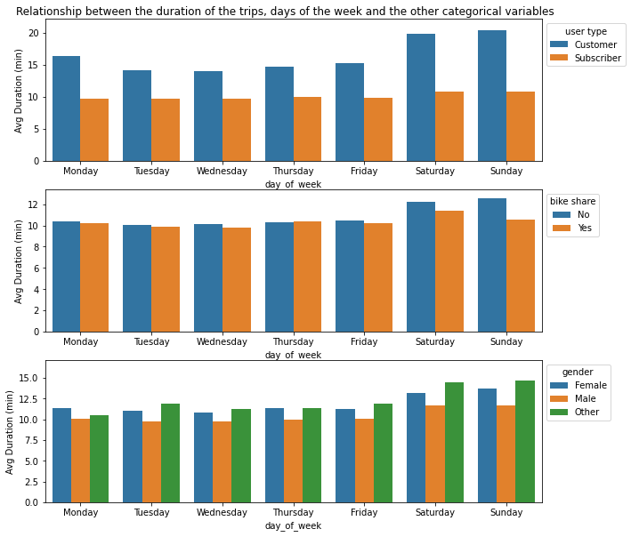

### RELATIONSHIP BETWEEN THE DURATION OF THE TRIPS, HOURS OF THE DAY AND THE OTHER CATEGORICAL VARIABLES

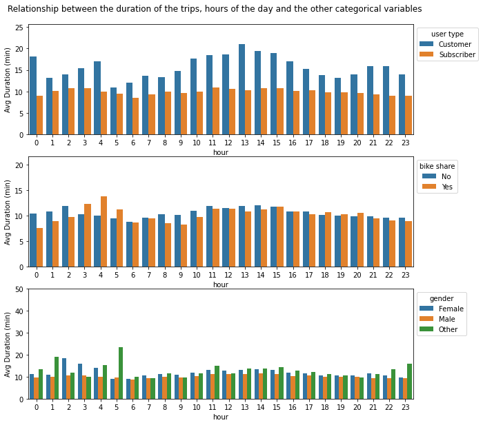

### RELATIONSHIP BETWEEN THE AGE OF THE MEMBERS, HOURS OF THE DAY AND THE OTHER CATEGORICAL VARIABLES

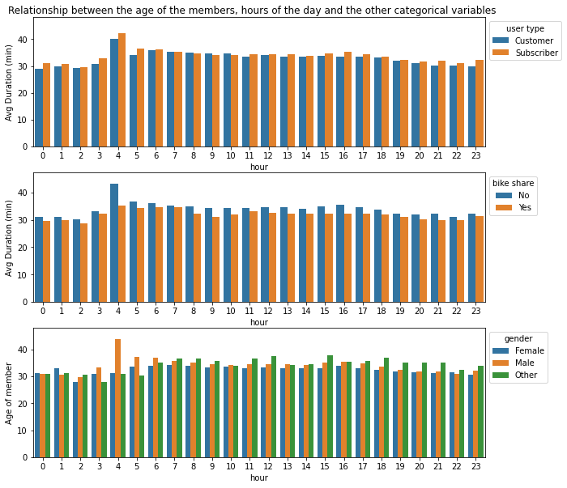

### RELATIONSHIP BETWEEN THE AGE OF THE MEMBERS, DAYS OF THE WEEK AND THE OTHER CATEGORICAL VARIABLES

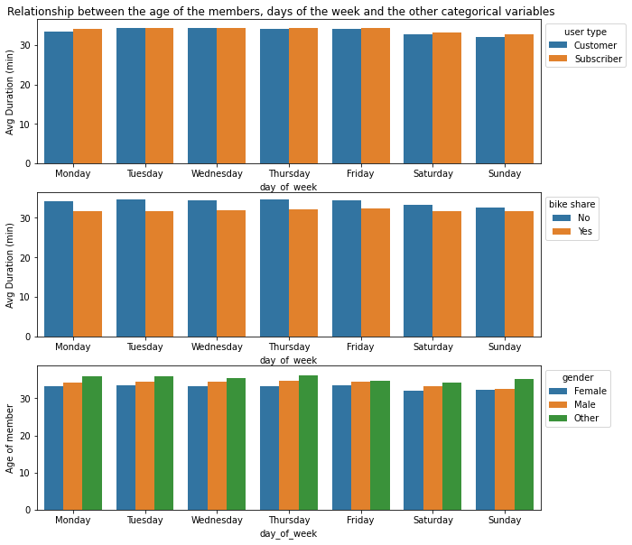

### RELATIONSHIP BETWEEN THE DURATION OF THE TRIPS, AGE OF THE MEMBERS AND THE CATEGORICAL VARIABLES

#### Day of the week

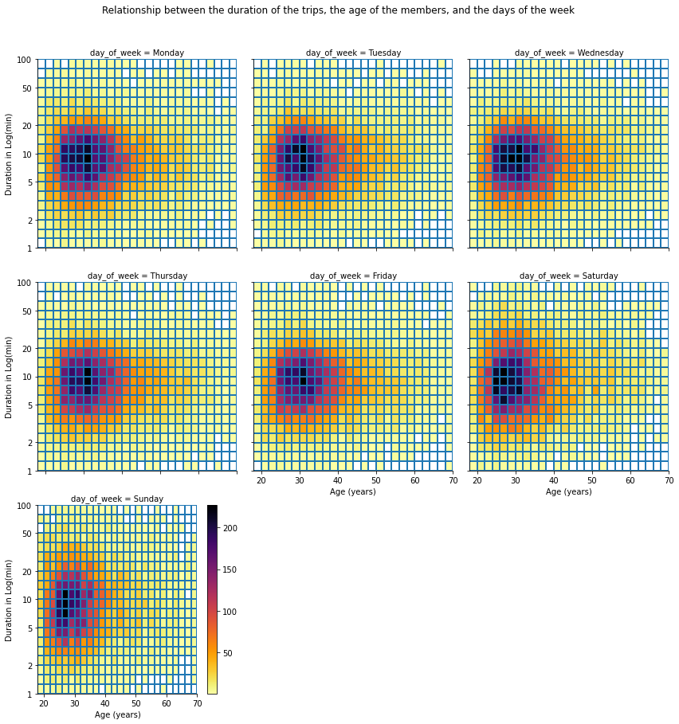

#### Hours of the week

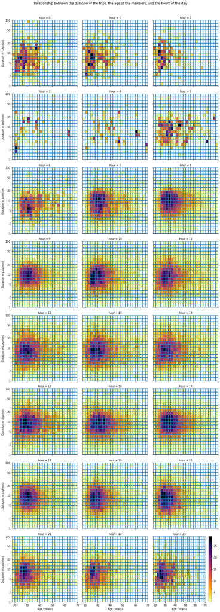

#### User Type

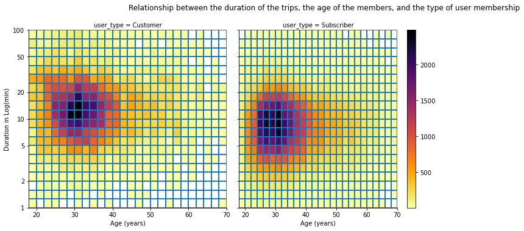

#### Gender

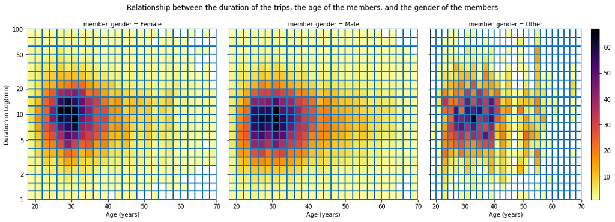

#### Bike Share For All Trip

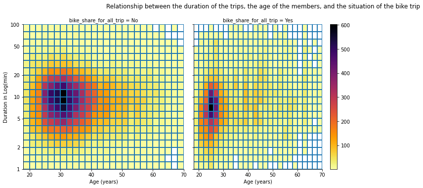